# Lecture 13 Tid-til-event analyse

Medicinsk statistik - MEDIS 5. Semester - Efterår 2026

Lars Hernández Nielsen

l.boerty@rn.dk | laboni@dcm.aau.dk

Assistant professor - Center for Danish Health Services Research

2026-11-12

## About Me (Lars Hernández Nielsen)

**Background**

- Economics (cand.oecon)
- PhD (epidemiology and biostatistics)
- Currently: Assistant professor (MMA)

**Interests**

- Data visualization, Statistics and epidemiology
- Health economics
- Large Language Models
- R/SQL/SAS

**Research**

- Observational research (registry data)
- Cancer (hematology/oncology)
- Collaboration with pharma industry

*Office 3rd floor 11.03.050* *You are free to stop by and ask questions*

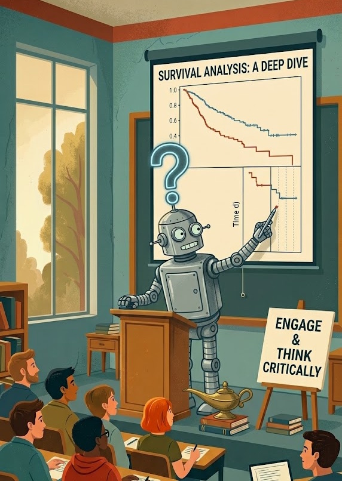

# Today’s lecture

**Learning objectives**

- Be able to compare mortality between two patient groups
- Be able to make adjusted comparison of mortality between two patient groups

**Curriculum**

Applied survival analysis using R (Moore et al. 2016) chapter 2, 3, 4 and 5. The .pdf is available to download with an AAU user.

**Agenda**

- The survival and hazard function
- Censoring
- Kaplan-Meier estimator
- Life tables
- Log Rank test
- The Cox Proportional Hazards model

[figure not shown]

# Time-to-event data

Many names, time-to-event analysis, **survival analysis**, failure time analysis, duration analysis, etc.

## POLLUX trial 2016 - example of survival analysis

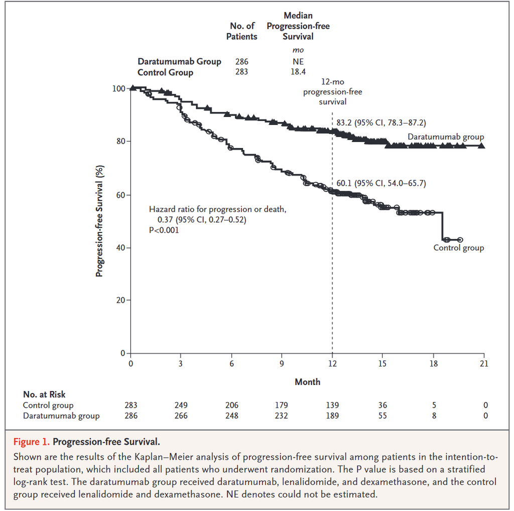

Source: (Dimopoulos et al. 2016)

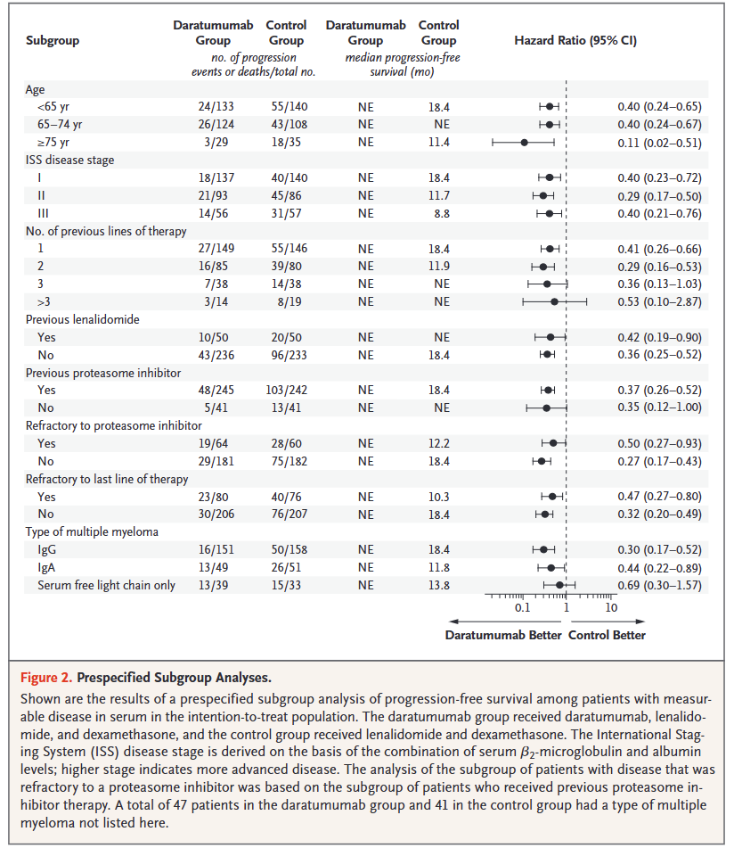

## Packages today

```r
library(tidyverse)
library(survival)
library(patchwork)
library(broom)
library(survminer)
library(forestmodel)
library(haven)
library(reactable)

base <- "#1f77b4"
```

## Time-to-event data

Image we include 10 patients between 2010 and 2020, we can illustrate them like this:

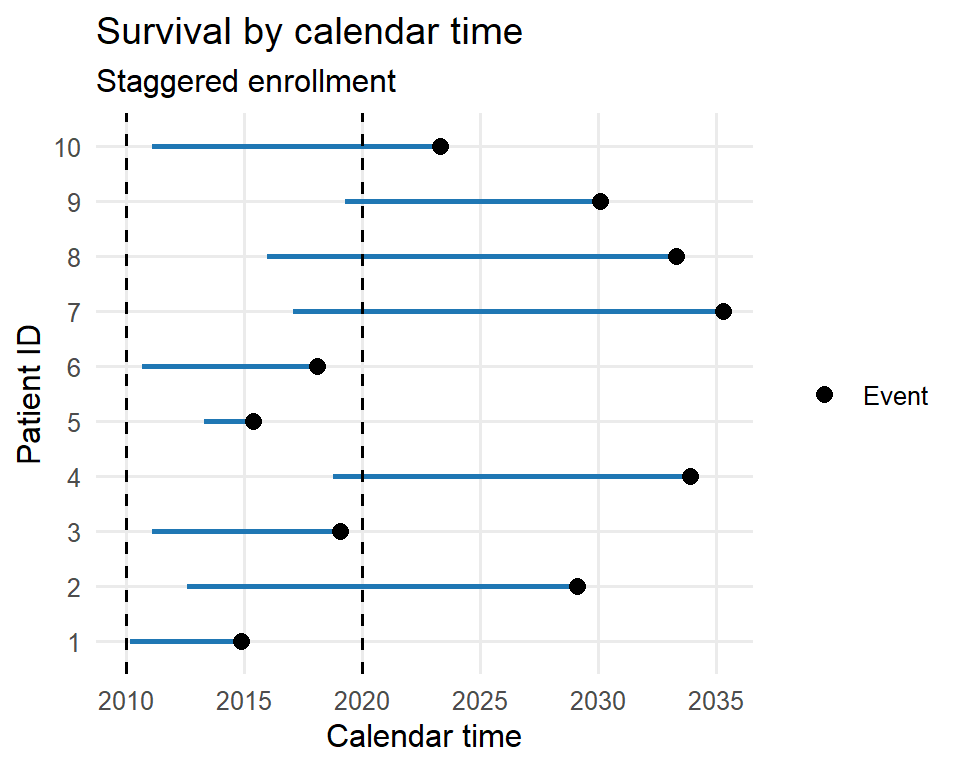

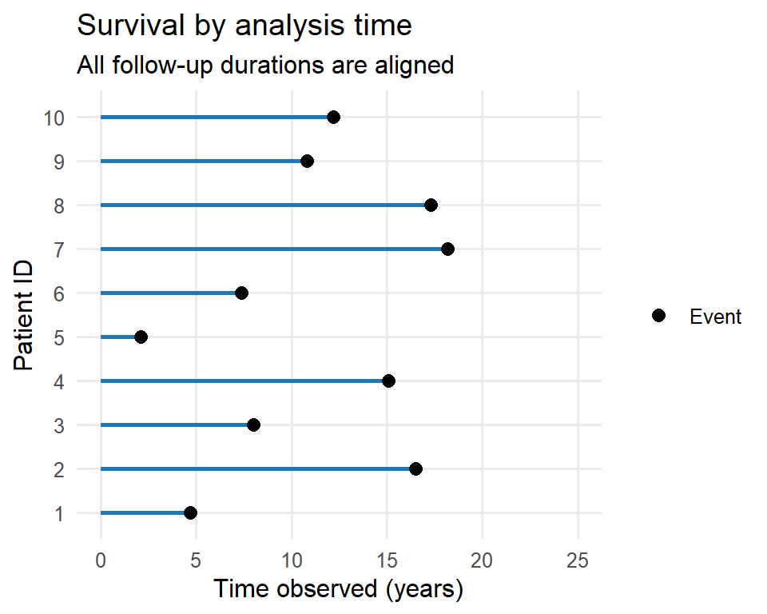

## Time-to-event data

To get the survival function we simply order the observations by their length

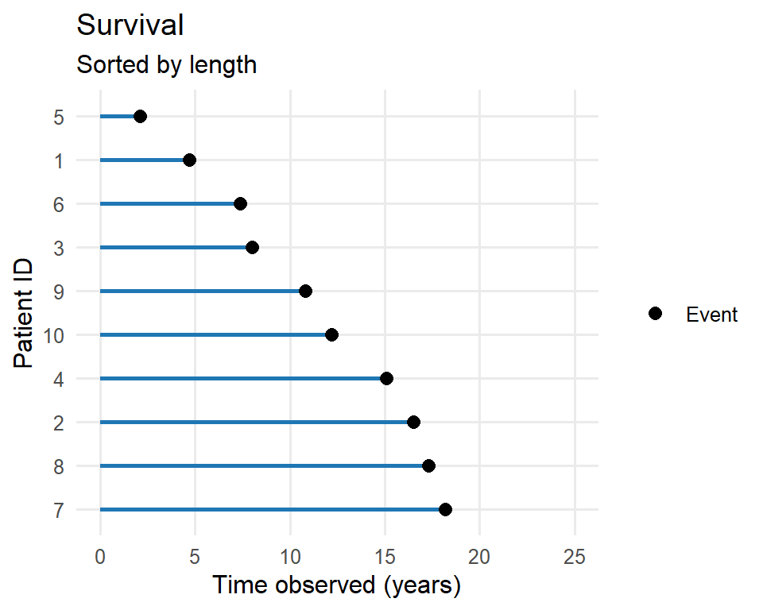

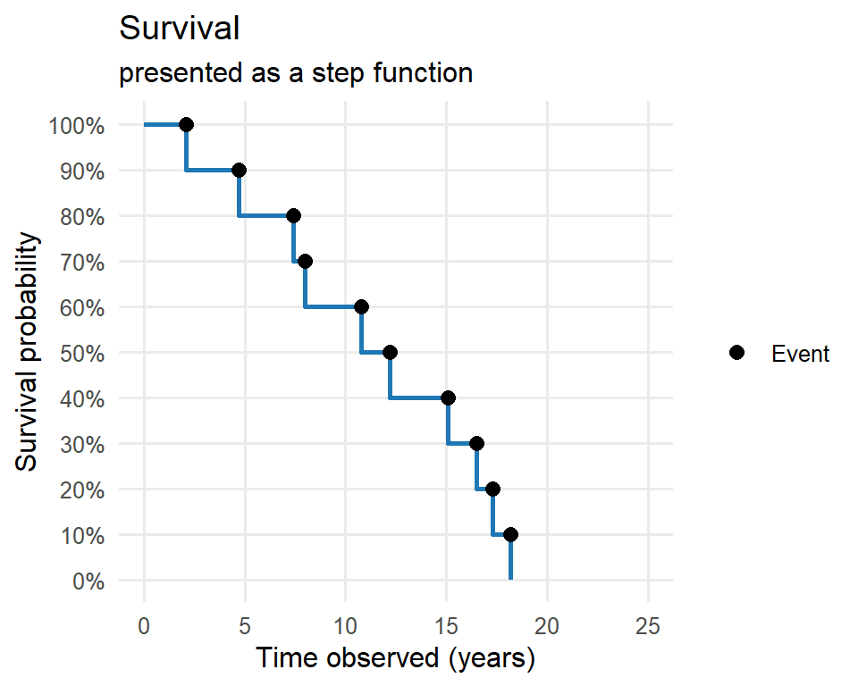

## The survival function

The survival function is a function that gives the probability that a patient (or other object of interest) will survive past a certain time.

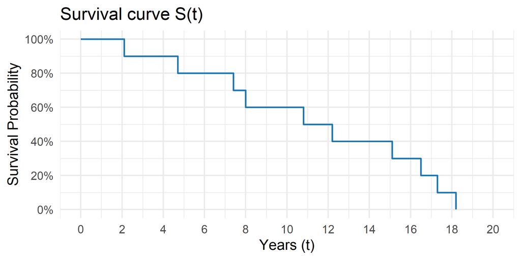

$$S(t) = pr(T>t),\quad0<t<\infty$$

Example of the survival function:

$$\begin{align}
S(t)&=\text{survival at time }t\\
S(3) &= 90\% \\
S(14) &= 40\%
\end{align}$$

If we assume our data is a sample of $n$ patients from a population , as $n \xrightarrow{} \infty$ we approximate the true survivor function.

## What is our problem here? what are we missing?

## Censoring

We almost never have fully observed data. Lets say we only have data until 2026

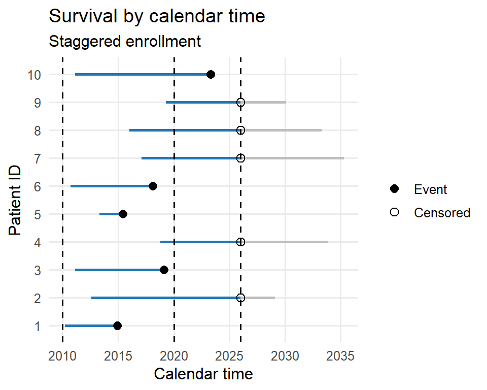

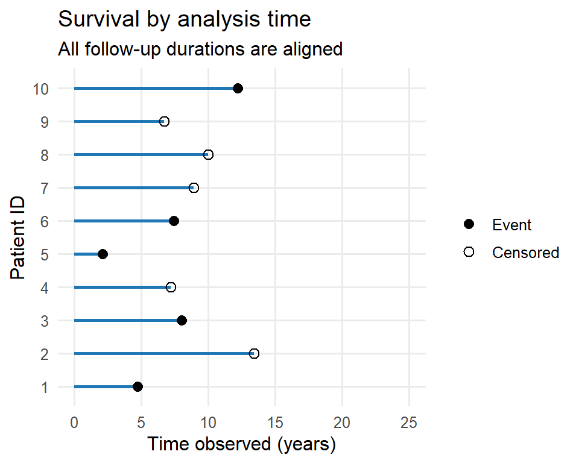

## Censoring our example

We can’t draw the full survival curve as not everyone experiences the event (dies). However we still know the follow-up time (survival) for each patient.

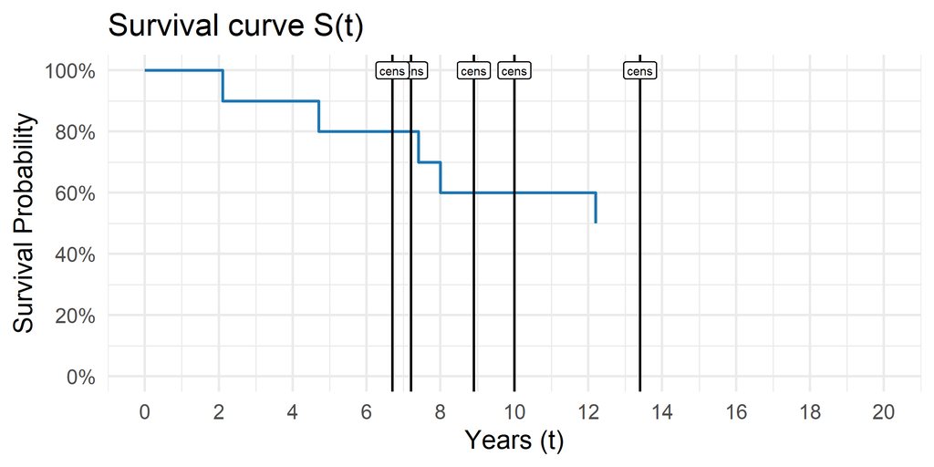

$$S(11) = \textbf{?}$$

We don’t know when the censored patients die!

# The Kaplan-Meier estimator

The estimator of the survival function $S(t)$ (the probability that life is longer than $t$) is given by:

$$\hat{S}(t)=\prod_{i:t_i\leq t}{\left(1-\frac{d_i}{n_i}\right)}$$

with $t_i$ a time when at least one event happened, $d_i$ the number of events (e.g., deaths) that happened at time $t_i$, and $n_i$ the individuals known to have survived (have not yet had an event or been censored) up to time $t_i$.

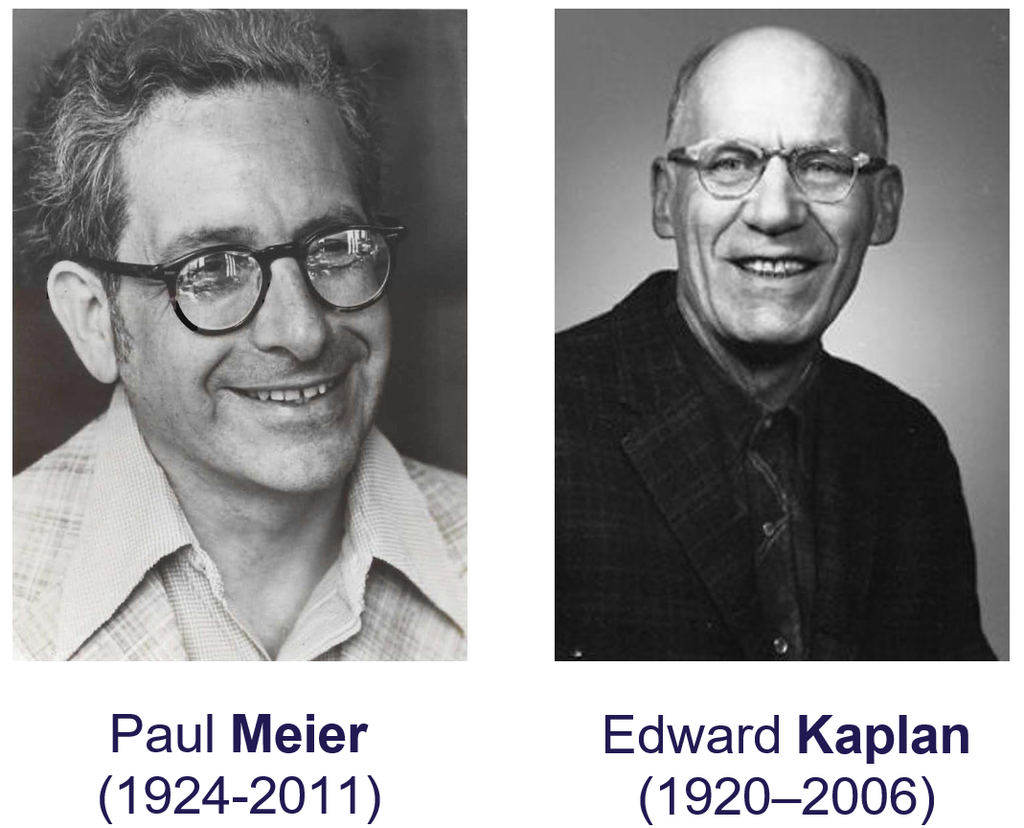

## Kaplan-Meier estimator

How it works is that censored observations doesn’t “influence” the curve until next event (death), where it goes lower due to fewer at risk. The Kaplan-Meier estimate of the survival function is marked with the dashed line.

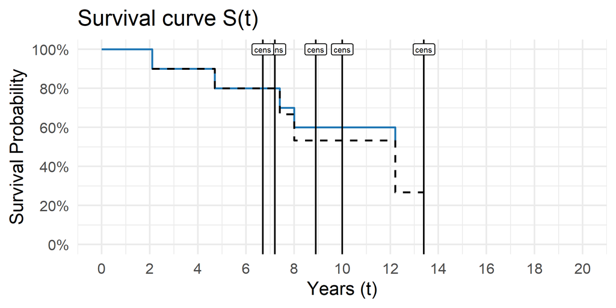

As we can see the last drop is large, as 4 patients are censored.

- It doesn’t end in 0% as the last time point is censored
- The Kaplan-Meier estimator is defined up to the maximum observed time point in the dataset

## Calculating KM by hand

$$\hat{S}(t)=\prod_{i:t_i\leq t}{\left(1-\frac{d_i}{n_i}\right)}$$
Data from our case from before:

[output not shown]

## Lets code the KM function in R

## Example KM

First we need some data, the dataset `lung` can always be called in R

```r
head(lung)
```

```
  inst time status age sex ph.ecog ph.karno pat.karno meal.cal wt.loss
1    3  306      2  74   1       1       90       100     1175      NA
2    3  455      2  68   1       0       90        90     1225      15
3    3 1010      1  56   1       0       90        90       NA      15
4    5  210      2  57   1       1       90        60     1150      11
5    1  883      2  60   1       0      100        90       NA       0
6   12 1022      1  74   1       1       50        80      513       0
```

This dataset contains a time (survival) and status (censoring) variable which is what we need to plot a survival curve. We can try our function with this data.

```r
S <- function(data, time, status) {

  t_i <- data[["time"]] |> sort() |> unique()
  n_i <- map_int(t_i, ~ nrow(data[data[["time"]] >= .x,]))
  d_i <- map_int(t_i, ~ nrow(data[data[["time"]] == .x & data[["status"]] == 2,]))

  tibble(t_i, n_i, d_i, survival = cumprod(1 - d_i / n_i))
}
```

$$\hat{S}(t)=\prod_{i:t_i\leq t}{\left(1-\frac{d_i}{n_i}\right)}$$

## Example KM

```r
survfit(Surv(time, status) ~ 1, data = lung)
```

```
Call: survfit(formula = Surv(time, status) ~ 1, data = lung)

       n events median 0.95LCL 0.95UCL
[1,] 228    165    310     285     363
```

```r
survfit(Surv(time, status) ~ sex, data = lung)
```

```
Call: survfit(formula = Surv(time, status) ~ sex, data = lung)

        n events median 0.95LCL 0.95UCL
sex=1 138    112    270     212     310
sex=2  90     53    426     348     550
```

```r
fit <- survfit(Surv(time, status) ~ 1, data = lung)
summary(fit, times = c(10, 100, 500))
```

```
Call: survfit(formula = Surv(time, status) ~ 1, data = lung)

 time n.risk n.event survival std.err lower 95% CI upper 95% CI
   10    227       1    0.996 0.00438        0.987        1.000
  100    196      30    0.864 0.02271        0.821        0.910
  500     41     107    0.293 0.03508        0.232        0.371
```

## Your turn

- Load the lung dataset in a new R session `lung <- lung`
- Use the `survfit()` and `Surv()` funtion to estimate the survival curve using Kaplan-Meier
- Stratify by ph.ecog
- Use `plot()` and `summary()` on the fit

## Example KM

```r
S(time = time, status = status, data = lung) |>
  head()
```

```
# A tibble: 6 × 4
    t_i   n_i   d_i survival
  <dbl> <int> <int>    <dbl>
1     5   228     1    0.996
2    11   227     3    0.982
3    12   224     1    0.978
4    13   223     2    0.969
5    15   221     1    0.965
6    26   220     1    0.961
```

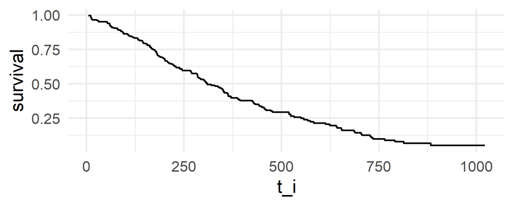

```r
S(time = time, status = status, data = lung) |>
  ggplot(aes(t_i, survival)) +
  geom_step() + theme_minimal(base_size = 26)
```

```r
survfit(Surv(time, status) ~ 1, data = lung) |>
  tidy() |> select(1:3,5) |> head()
```

```
# A tibble: 6 × 4
   time n.risk n.event estimate
  <dbl>  <dbl>   <dbl>    <dbl>
1     5    228       1    0.996
2    11    227       3    0.982
3    12    224       1    0.978
4    13    223       2    0.969
5    15    221       1    0.965
6    26    220       1    0.961
```

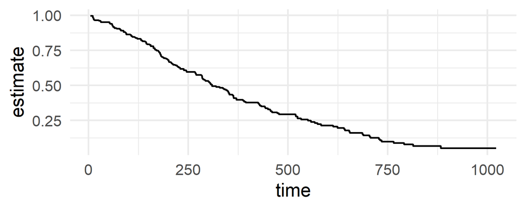

```r
survfit(Surv(time, status) ~ 1, lung) |>
  tidy() |> ggplot(aes(time, estimate)) +
  geom_step() + theme_minimal(base_size = 26)
```

## Confidence intervals on KM

Commonly calculated using Greenwood’s formula:

$$\widehat{\text{Var}}\left(\hat{S}(t)\right) = \left[\hat{S}(t)\right]^2 \sum_{i:\, t_i \le t} \frac{d_i}{n_i(n_i - d_i)}$$

Represent both the uncertainty due to censoring, but also the general sampling bias we have in small samples

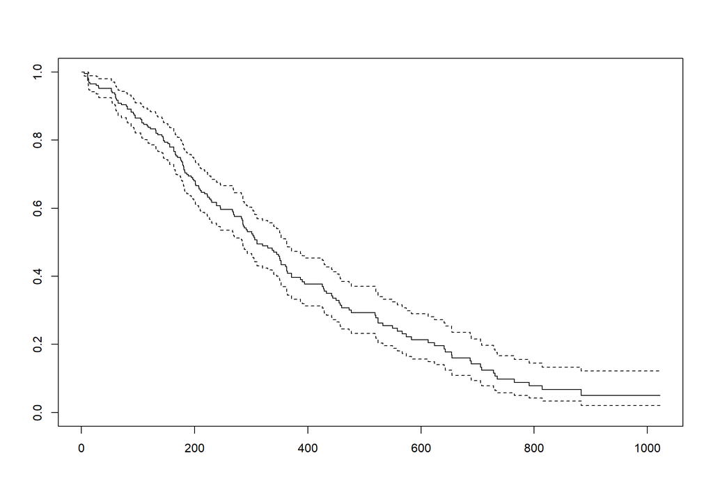

```r
survfit(Surv(time, status) ~ 1, data = lung) |> plot()
```

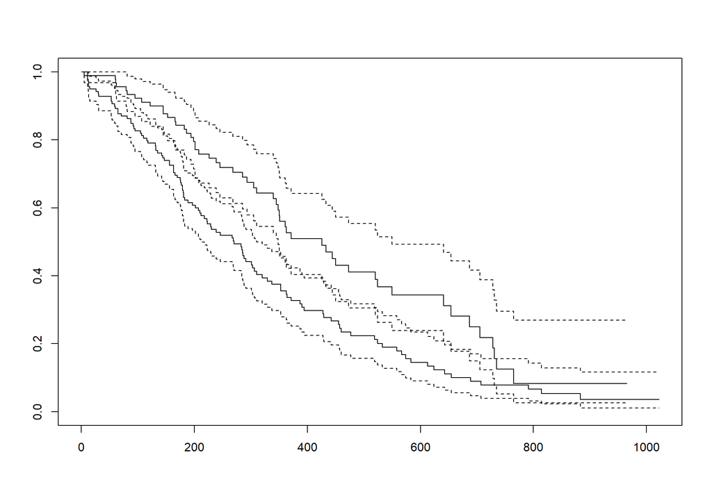

```r
survfit(Surv(time, status) ~ sex, data = lung) |> plot(conf.int=T)
```

## Publication ready survival curves

However, when plotting survival curves we often want some more info (risk table, censoring, etc.). Therefore i use the package `survminer`.

```r
lung2 <- lung |>
  mutate(sex = if_else(sex == 1, "Male","Female"),
         age_group = case_when(between(age, 0,59) ~ "35 - 59 years",
                               between(age, 60,69) ~ "60 - 69 years",
                               between(age, 70,99) ~ "70 - 85 years"))

surv_plot <- function(data, strat, plot_title) {

  dat <- data[!is.na(data[[strat]]),]
  dat$time <- dat$time/365
  labs <- sort(unique(dat[[strat]]))

  splot <- survminer::ggsurvplot(fit = surv_fit(as.formula(paste0("Surv(time, status) ~", strat)), data = dat),
                                 data = dat,
                                 palette = c("#0B0405FF", "#40498EFF","#38AAACFF", "#DEF5E5FF"),
                                 ggtheme = theme_bw(), xlim = c(0,2.5),
                                 break.time.by = 0.5,
                                 pval = TRUE,
                                 pval.method = TRUE,
                                 pval.size = 3.5,
                                 pval.coord = c(0,0.05),
                                 pval.method.coord = c(0,0.12),
                                 risk.table = "nrisk_cumcensor",
                                 risk.table.y.text = FALSE,
                                 risk.table.height = 0.3,
                                 tables.y.text = TRUE,
                                 fontsize = 3, size = 0.2,
                                 conf.int = TRUE,
                                 conf.int.alpha = 0.2,
                                 conf.int.style = "ribbon",
                                 censor = T, censor.shape = 124, censor.size = 2, legend.labs = labs)

  splot$plot <- splot$plot +
    labs(title = paste(plot_title), fill = NULL, color = NULL, x = "Time from diagnosis (years)") +
    scale_y_continuous(labels = scales::percent_format())+
    guides(color = guide_legend(override.aes = list(shape = NA, linewidth=0.6)))+
    theme(panel.grid = element_blank(),
          panel.border = element_rect(color="black", fill=NA, linewidth=0.6),
          legend.justification = c(1,1),
          legend.key.size = unit(4,"mm"),
          legend.spacing.y = unit(0,"mm"),
          legend.background = element_rect(color="black", fill=NA, linewidth = 0.6*0.5),
          legend.position = c(1,1),
          legend.box.margin = margin(t = 0.6*(.pt*72.27/96/4), r = 0.6*(.pt*72.27/96/4)),
          axis.ticks = element_line(color="black"),
          axis.text = element_text(color="black"),
          axis.title = element_text(size = 10, color="black"),
          plot.background = element_rect(fill="white"),
          plot.tag.position = c(0,1))

  splot$table <- splot$table +
    labs(title="No. at risk (No. censored)", x = NULL, y = NULL) +
    coord_cartesian(clip = "off", xlim=c(0,2.5),ylim=c(0,3)) +
    theme(panel.grid = element_blank(),
          plot.title = element_text(size=10),
          panel.border = element_rect(color = NA),
          axis.ticks.x = element_blank(),
          axis.text.x = element_blank())
  splot
}

pl <- list(surv_plot(data = lung2, strat = "age_group", plot_title = "Overall survival by age group"),
           surv_plot(data = lung2, strat = "sex", plot_title = "Overall survival by sex"))

pl[[2]]$table <- pl[[2]]$table + coord_cartesian(clip = "off", xlim=c(0,2.5),ylim=c(-1,2))

p <- pl[[1]]$plot + pl[[2]]$plot + pl[[1]]$table + pl[[2]]$table +
  plot_layout(design = "AB\nCD", height=c(1,0.3))

p
```

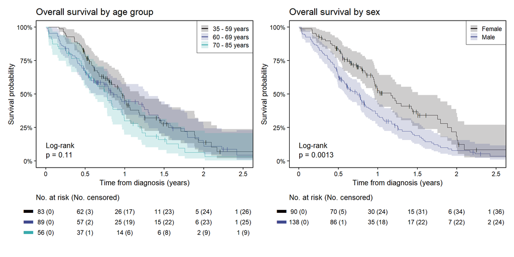

See here for code example on my [Linkedin](https://www.linkedin.com/pulse/beautiful-survival-plots-r-lars-hern%C3%A1ndez-nielsen-mqeof)

## Alternative endpoints

Currently we have talked about survival, commonly refered as **overall survival (OS)**.

- Overall survival (OS) (most commonly used)
- Progression free survival (PFS/PF$) (common in palliative treatment)
- Disease free survival (DFS) (common in adjuvant treatment)
- Relapse free survival (RFS)
- Event free survival (EFS)
- Time to progression (TTP)

Definitions (what is censoring, what is event, when does time start) of some of the more exotic can differ.

## Coding OS and PFS

Genereally to perform a survival analysis 3 dates are needed (to generate the status/event/delta variable and the time/survival variable)

- Date of start (e.g. diagnosis)
- Date of event (e.g. death)
- Date of censoring (e.g. administrative censoring)

In general the status indicator is coded 1 if there is a date of event, and 0 if this is missing. The time variable is coded as time difference between date of start and date of event for all that has the event, and date of start and date of end of study for everyone else.

**For public data status and time are often pre-calculated as dates are sensitive.** In observational studies made with registry data they have to be coded manually. When changing endpoint we need to redo variables.

## Types of censoring

**Censoring** - You know the subject exists, but exact event time is incomplete.

- **Right censoring:** Event occurs after observation ends.
  - Administrative censoring: Subjects are censored at a cutoff date, often same as date of as last data update.
  - Loss to follow-up: Subjects status are unknown, e.g. due to moving to another country.
- **Left censoring:** Event occurred before observation began, but exact time is unknown.
- **Interval-censoring:** The exact event time unknown, but is known to have occurred between two specific points in time.

**Truncation** - Systematic sampling bias; subject is entirely missing from data.

- **Left truncation:** Subjects enter study only if they survive until study start.
- **Right truncation:** Subjects observed only if event happens before cutoff time.

## Illustration of censoring

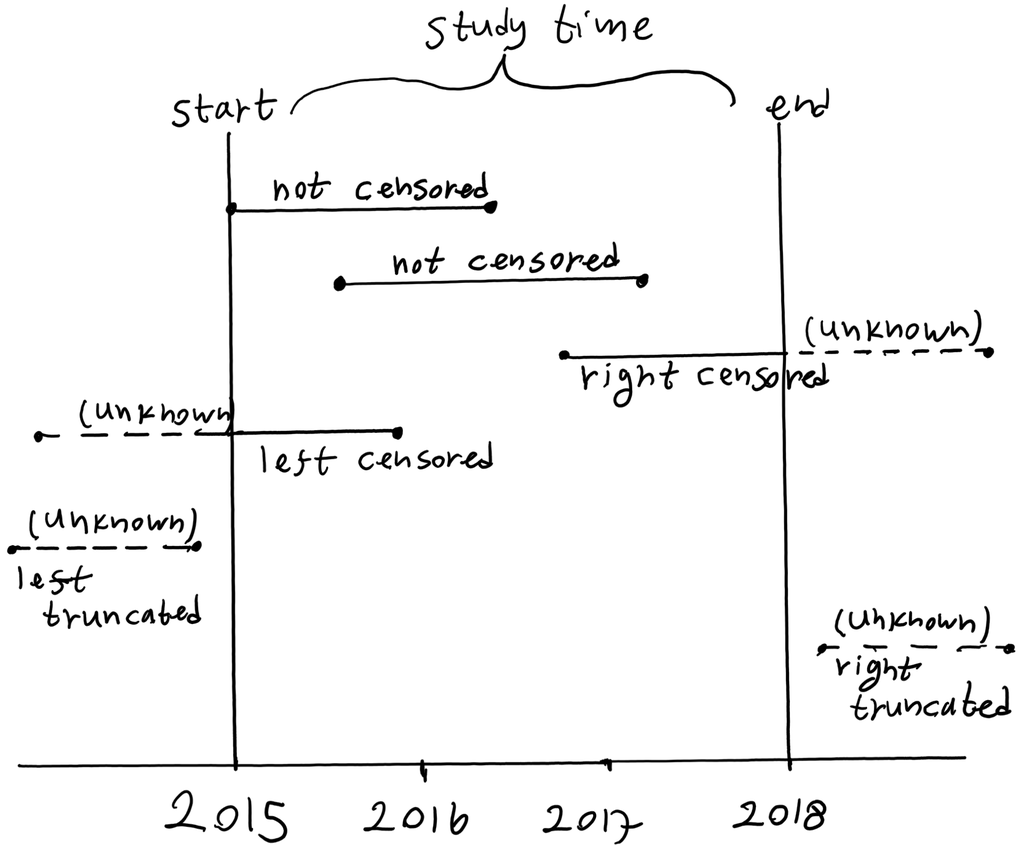

# AMGEN Panitumumab trial

This example is based on real trial data from [Project Data Sphere (PDS)](https://data.projectdatasphere.org/projectdatasphere/html/home) for the clinical trial: **the PRIME study - Panitumumab AMG 954 20050203**

> **Protocol:** A Randomized, Multicenter, Phase 3 Study to Compare the Efficacy of Panitumumab in Combination with Oxaliplatin/ 5-fluorouracil/ leucovorin (FOLFOX) to the Efficacy of >Oxaliplatin/ 5-fluorouracil/ leucovorin (FOLFOX) Alone in Patients with Previously Untreated Metastatic Colorectal Cancer. EudraCT: 2006-000170-70.
> - Primary results 2010: 10.1200/jco.2009.27.4860
> - Final results 2014:10.1093/annonc/mdu141

CDISC ADS/ADaM

## AMGEN Panitumumab trial

We load the data from a SAS file.

```r
pds <- read_sas("AMG_data/PDS_DSA_20050203/adsl_pds2019.sas7bdat", NULL) |>
  mutate(DTHMO = round(DTHDY/30.43,1),
         PFSMOCR = round(PFSDYCR/30.43,1))
```

To include the KRAS subtype we load the dataset with biomarker data.

```r
biomark <- read_sas("AMG_data/PDS_DSA_20050203/biomark_pds2019.sas7bdat", NULL) |>
  select(SUBJID, BMMTR1)

pds <- pds |>
  left_join(biomark) |>
  mutate(KRAS = case_when(BMMTR1 == "Wild-type" ~ "WT",
                          BMMTR1 == "Mutant"    ~ "MT",
                          TRUE                  ~ "Missing"))

pds_WT <- pds |>
  filter(KRAS == "WT")
```

## AMGEN Panitumumab trial

Here we can see some of the data.

```r
pds |> select(-DTHDY,-PFSDYCR,-BMMTR1,-B_ECOG,-HISSUBTY,-DIAGMONS, -B_METANM, -ATRT) |>
  reactable(bordered = T, defaultPageSize = 6, style = list(fontSize = "18px"))
```

| SUBJID | TRT | PRSURG | DTH | PFSCR | LIVERMET | AGE | SEX | B_WEIGHT | B_HEIGHT | RACE | DIAGTYPE | DTHMO | PFSMOCR | KRAS |
| --- | --- | --- | --- | --- | --- | --- | --- | --- | --- | --- | --- | --- | --- | --- |
| 000001 | FOLFOX alone | Y | 1 | 1 | Y | 64 | Male | 64.2 | 167 | White or Caucasian | Colon | 18.3 | 18.3 | Missing |
| 000003 | Panitumumab + FOLFOX | Y | 1 | 1 | Y | 65 | Male | 67 | 165 | White or Caucasian | Colon | 9.9 | 1.8 | MT |
| 000004 | FOLFOX alone | Y | 1 | 1 | Y | 60 | Male | 75 | 175 | White or Caucasian | Colon | 15.1 | 9.6 | MT |
| 000005 | FOLFOX alone | Y | 1 | 1 | Y | 64 | Female | 52 | 160 | White or Caucasian | Colon | 31.7 | 31.7 | MT |
| 000006 | FOLFOX alone | N | 1 | 1 | Y | 74 | Male | 66 | 171 | White or Caucasian | Rectal | 6.9 | 1.8 | Missing |
| 000007 | Panitumumab + FOLFOX | Y | 1 | 1 | Y | 52 | Female | 53 | 160 | Hispanic or Latino | Colon | 11.1 | 11.1 | MT |
| 000008 | FOLFOX alone | Y | 1 | 1 | N | 47 | Male | 75 | 174 | White or Caucasian | Colon | 24 | 4 | MT |
| 000009 | Panitumumab + FOLFOX | Y | 1 | 1 | Y | 42 | Female | 69 | 148 | Hispanic or Latino | Colon | 22.9 | 9.9 | Missing |
| 000010 | FOLFOX alone | Y | 1 | 1 | Y | 54 | Female | 46.8 | 148 | White or Caucasian | Colon | 18.1 | 18.1 | MT |
| 000013 | Panitumumab + FOLFOX | Y | 1 | 1 | Y | 54 | Male | 62 | 160 | White or Caucasian | Rectal | 6.5 | 2.4 | WT |

[output cut: 925 more lines]

## OS estimate Panitumumab

```r
survfit(Surv(DTHMO, DTH) ~ TRT, data = pds)
```

```
Call: survfit(formula = Surv(DTHMO, DTH) ~ TRT, data = pds)

                           n events median 0.95LCL 0.95UCL
TRT=FOLFOX alone         466    350   19.4    17.4    21.8
TRT=Panitumumab + FOLFOX 469    340   19.6    18.0    21.7
```

Here we see that for the whole cohort there is no difference in OS.

Wildtype subset:

```r
survfit(Surv(DTHMO, DTH) ~ TRT, data = pds_WT)
```

```
Call: survfit(formula = Surv(DTHMO, DTH) ~ TRT, data = pds_WT)

                           n events median 0.95LCL 0.95UCL
TRT=FOLFOX alone         254    176   20.5    17.8    23.6
TRT=Panitumumab + FOLFOX 260    170   23.9    20.3    28.0
```

However when we only look at WT patients the median survival is 3.4 months longer.

## PFS estimate Panitumumab

```r
survfit(Surv(PFSMOCR, PFSCR) ~ TRT, data = pds_WT)
```

```
Call: survfit(formula = Surv(PFSMOCR, PFSCR) ~ TRT, data = pds_WT)

                           n events median 0.95LCL 0.95UCL
TRT=FOLFOX alone         254    213    9.2     7.7    10.9
TRT=Panitumumab + FOLFOX 260    212    9.6     9.2    11.3
```

We find 0.4 months longer median progression free survival for the treated group.

## Life tables

When we present the probabilities of survival at different time points we call it life tables.

e.g. here we see that for the FOLFOX alone the 3 year survival rate is 28%.

```r
survfit(Surv(DTHMO, DTH) ~ TRT, data = pds_WT) |> summary(times = c(1,6,12,18,24,36))
```

```
Call: survfit(formula = Surv(DTHMO, DTH) ~ TRT, data = pds_WT)

                TRT=FOLFOX alone
 time n.risk n.event survival std.err lower 95% CI upper 95% CI
    1    252       0    1.000  0.0000        1.000        1.000
    6    225      23    0.908  0.0183        0.873        0.944
   12    182      43    0.734  0.0280        0.681        0.791
   18    137      44    0.556  0.0316        0.497        0.621
   24    101      34    0.416  0.0315        0.359        0.483
   36     33      28    0.282  0.0303        0.228        0.348

                TRT=Panitumumab + FOLFOX
 time n.risk n.event survival std.err lower 95% CI upper 95% CI
    1    257       3    0.988 0.00662        0.976        1.000
    6    229      21    0.906 0.01819        0.871        0.943
   12    181      44    0.731 0.02796        0.678        0.787
   18    154      26    0.625 0.03067        0.567        0.688
   24    120      31    0.497 0.03184        0.438        0.564
   36     48      40    0.321 0.03067        0.266        0.387
```

# Log Rank test

What if we want to compare two survival curves? One way to do this in R is using the `survdiff()` function (log rank test).

```r
survdiff(Surv(DTHMO, DTH) ~ TRT, data = pds_WT)
```

```
Call:
survdiff(formula = Surv(DTHMO, DTH) ~ TRT, data = pds_WT)

                           N Observed Expected (O-E)^2/E (O-E)^2/V
TRT=FOLFOX alone         254      176      166     0.591      1.14
TRT=Panitumumab + FOLFOX 260      170      180     0.546      1.14

 Chisq= 1.1  on 1 degrees of freedom, p= 0.3
```

```r
survdiff(Surv(PFSMOCR, PFSCR) ~ TRT, data = pds_WT)
```

```
Call:
survdiff(formula = Surv(PFSMOCR, PFSCR) ~ TRT, data = pds_WT)

                           N Observed Expected (O-E)^2/E (O-E)^2/V
TRT=FOLFOX alone         254      213      194      1.87      3.51
TRT=Panitumumab + FOLFOX 260      212      231      1.57      3.51

 Chisq= 3.5  on 1 degrees of freedom, p= 0.06
```

Log Rank is a non-parametric method for equality of survival distributions using the full survival data without making any assumption about the shape of the survival curves. For two groups (e.g. different treatments) with hazard function $h_{A}$ and $h_{B}$.

I.e. null hypothesis is $H_0 : h_{A}(·) = h_{B}(·)$, which is similar to saying $H_0 : S_{A}(·) = S_{B}(·)$.

## Calculation of the Log Rank test

For each event time $t_i$, $O_{i,A}$ and $O_{i,B}$ are observed number of deaths in group $A$ (e.g. FOLFOX alone) and $B$ (e.g. Panitumumab + FOLFOX), respectively. $N_{i,A}$ and $N_{i,B}$ are observed number at risk in each group. The expected number deaths in group A assuming no difference between groups:

$$E_{i,A} = N_{i,A} \frac{O_{i,A} + O_{i,B}}{N_{i,A} + N_{i,B}}$$

The Log Rank score statistics:

$$Z = \frac{(O_{A} - E_{A})^2}{\text{var}(O_{A} - E_{A})} \approx \chi^2$$

$$O_{A} - E_{A} = \sum_{i} (O_{i,A} - E_{i,A})$$
Choice between $A$ and $B$ in calculating the statistic doesn’t matter, difference of $A$ to $B$ is the same as $B$ to $A$.

Remember Log-rank test says nothing about the magnitude of difference.

## Plotting KM-curves

```r
fit1 <- survfit(Surv(DTHMO, DTH) ~ TRT, data = pds_WT)
fit2 <- survfit(Surv(PFSMOCR, PFSCR) ~ TRT, data = pds_WT)

p1 <- ggsurvplot(fit1, risk.table = T, risk.table.y.text = F, break.time.by = 6, xlim = c(0, 48), pval = T, title = "OS", censor = T,
                 censor.shape = 124, censor.size = 2, palette = c("grey30", base))
p2 <- ggsurvplot(fit2, risk.table = T, risk.table.y.text = F, break.time.by = 6, xlim = c(0, 48), pval = T,title = "PFS", censor = T,
                 censor.shape = 124, censor.size = 2, palette = c("grey30", base))

p1$plot + p2$plot + p1$table + p2$table + plot_layout(height = c(1, 0.3)) & theme(legend.position = c(0.75, 0.9))
```

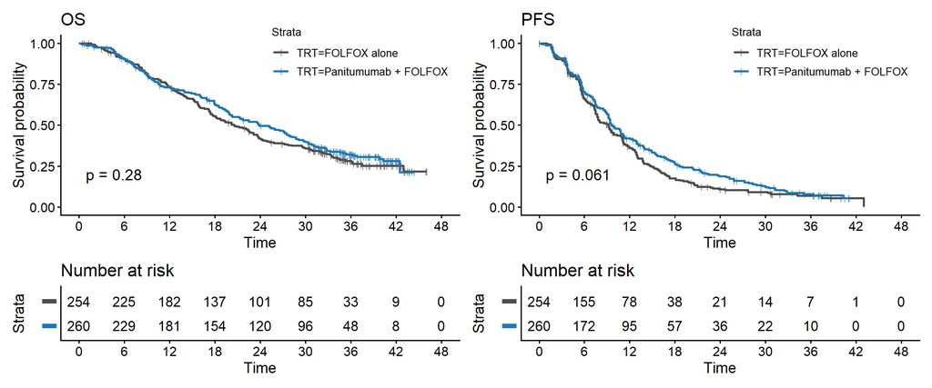

## Why does the PFS curve look like stairs?

# The Hazard Function

Hazard function $h(t)$ - Instantaneous rate of failure at time $t$

Not a risk but a rate - *speed of dying*

## The Hazard Function

The risk of dying before time $t+dt$ given that you are alive at $t$ is $P(t<T\leq t+dt|T>t)$: with $T$ a random variable denoting the time of death/event.

$$h(t) = \frac{P(t<T\leq t+dt|T>t)}{dt}$$
The hazard function represents the probability that a subject will experience an event in the next small interval of time, divided by the length of this interval, given that they have survived up to time $t$. Instantaneous rate of death, given that you are alive at $t$

Cumulative hazard function and survival function are given by:

$$H(t) = \int_{0}^{t} h(u) du \qquad\qquad S(t) = exp(-H(t))$$

Sometimes the hazard function is written as: $\lambda(t)$ and the cumulative hazard function as: $\Lambda(t)$

## Hazard example from book

**What do you think the hazard looks like for this population?**

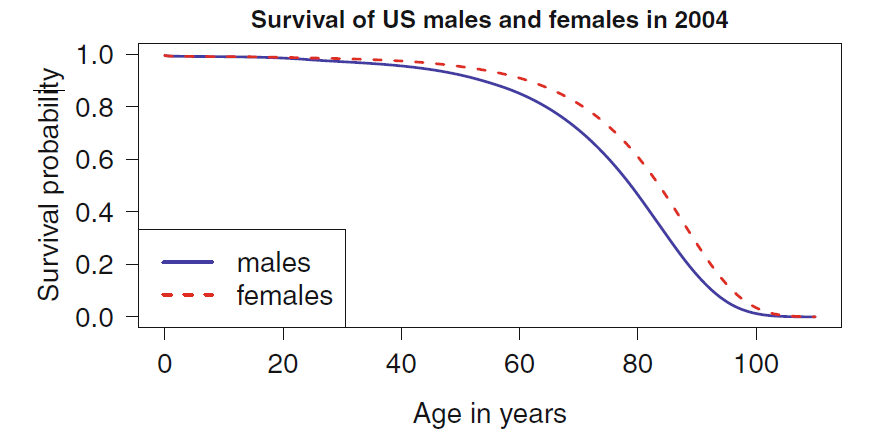

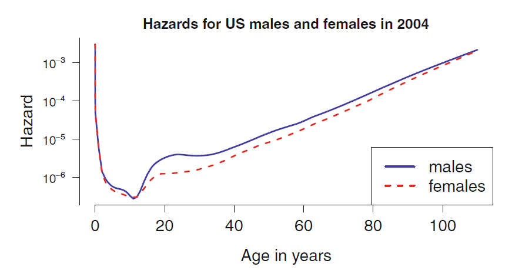

## The Hazard Function

Examples of 4 hazard functions and their corresponding survival curves:

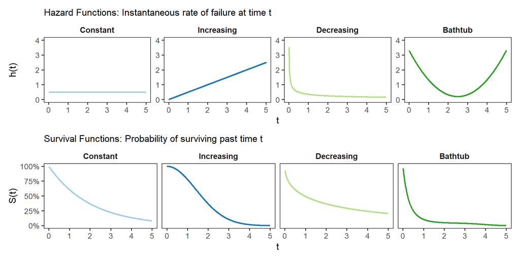

## The Hazard Function for our example

As the hazard is the instantaneous rate of failure it is 0 in between events, and infinite when an event hits. This is a problem going from discrete to continuous.

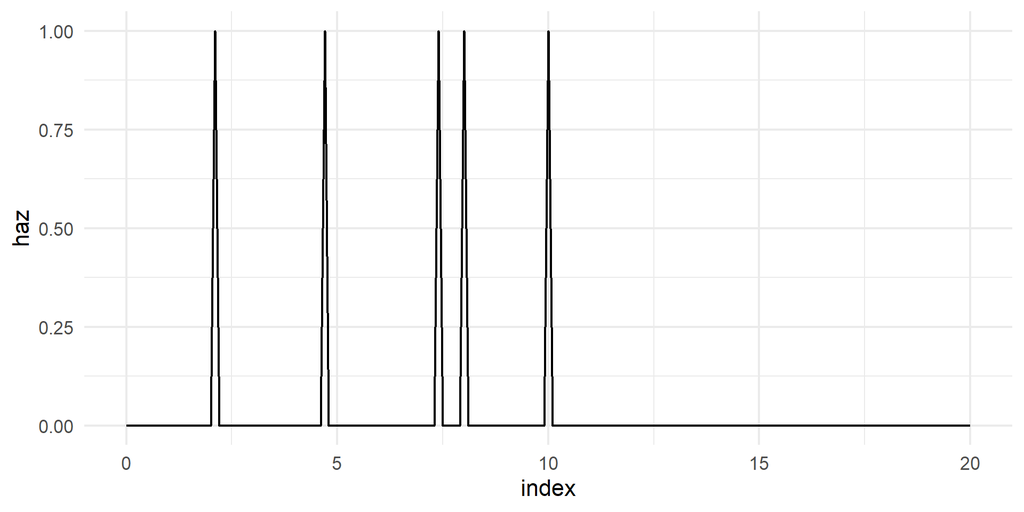

For this reason the hazard makes sense fitting some distribution, but this brings additional assumptions.

## Calculating hazard rates

If the hazard rate is assumed to be constant over time, you can calculate the crude hazard rate (incidence rate) for each group individually.

$$\text{Hazard rate} = \frac{N_{event}}{\text{person-time at risk}}$$

```r
epiR::epi.conf(cbind(ev = sum(pds_WT[pds_WT$TRT=="FOLFOX alone",]$DTH),
                     pt = sum(pds_WT[pds_WT$TRT=="FOLFOX alone",]$DTHMO)),
               ctype = "inc.rate", method = "exact")
```

```
          est      lower      upper
ev 0.03270221 0.02804917 0.03790659
```

```r
epiR::epi.conf(cbind(ev = sum(pds_WT[pds_WT$TRT=="Panitumumab + FOLFOX",]$DTH),
                     pt = sum(pds_WT[pds_WT$TRT=="Panitumumab + FOLFOX",]$DTHMO)),
               ctype = "inc.rate", method = "exact")
```

```
          est     lower      upper
ev 0.02927451 0.0250392 0.03402102
```

## What if we would like to adjust for a confounder?

# Cox Proportional Hazards model

Semi-parametric model that estimates hazard rate ratios (HR)

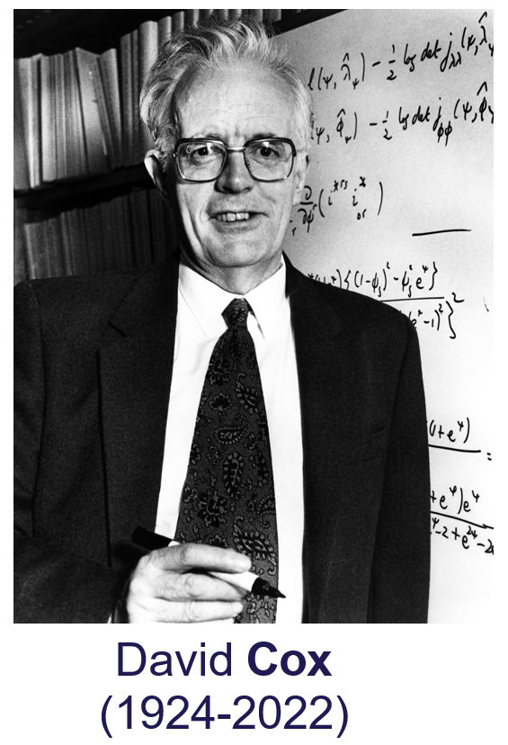

## Cox Proportional Hazards model

Hazard rate ratio (HR) Can be derived from the Proportional Hazards model, where the hazards can change over time, but only proportionally to each other.

The proportional hazard assumption is that all individuals have the same hazard function, but a unique scaling factor. The shape of the hazard function is the same for all individuals, and only a scalar multiple changes per individual.

$$H_i(t) = a_ih(t)$$

At the core of the assumption is that $a_i$ is not time varying, that is, $a_i(t)=a_i$. Furthermore, the ratio of this with another subject (called the hazard rate ratio (HR)) is constant for all $t$:

$$\frac{h_i(t)}{h_j(t)} = \frac{a_i h(t)}{a_j h(t)} = \frac{a_i}{a_j}$$

## Cox Proportional Hazards model

The Proportional Hazards model, a regression model:

$$h(t, X) = \exp(X\beta)h_b(t)$$
Where $\beta$ and the baseline hazard $h_b(t)$ are the unknown parameters estimated from data (non-parametric).

Interpretation of the $\beta$ coefficient

- $\beta > 0$ implies $HR > 1$
- $\beta = 0$ implies $HR = 1$
- $\beta < 0$ implies $HR < 1$

The null hypothesis $H_0:\beta=0$

Assumptions:

- Proportional Hazards
- Independent censoring

Effect of binary covariate on outcome for one patient

$$X = \begin{cases}
1 \text{ if individual receives treatment} \\
0 \text{ if individual receives SOC}
\end{cases}$$

$$HR = \frac{h(t, X=1)}{h(t, X=0)} = \frac{\exp(\beta)h_b(t)}{\exp(0)h_b(t)} = \exp(\beta)$$

## Cox Proportional Hazards model

What makes the CoxPH model special is that it does not assumes a specific shape or mathematical distribution for baseline hazard. It is estimated using partial likelihood (as opposed to maximum likelihood) where we don’t need to estimate the baseline hazard.

```r
coxph(Surv(DTHMO,DTH) ~ TRT, data = pds_WT) |> summary()
```

```
Call:
coxph(formula = Surv(DTHMO, DTH) ~ TRT, data = pds_WT)

  n= 514, number of events= 346

                           coef exp(coef) se(coef)      z Pr(>|z|)
TRTPanitumumab + FOLFOX -0.1149    0.8915   0.1077 -1.066    0.286

                        exp(coef) exp(-coef) lower .95 upper .95
TRTPanitumumab + FOLFOX    0.8915      1.122    0.7219     1.101

Concordance= 0.515  (se = 0.014 )
Likelihood ratio test= 1.14  on 1 df,   p=0.3
Wald test            = 1.14  on 1 df,   p=0.3
Score (logrank) test = 1.14  on 1 df,   p=0.3
```

## Adjusted CoxPH

We can add covariates to the model

$$h(t) = exp(x_1\beta_1+x_2\beta_2+...+x_j\beta_j)h_b(t)$$

```r
coxph(Surv(DTHMO,DTH) ~ TRT + AGE + SEX, data = pds) |> summary()
```

```
Call:
coxph(formula = Surv(DTHMO, DTH) ~ TRT + AGE + SEX, data = pds)

  n= 935, number of events= 690

                             coef exp(coef)  se(coef)      z Pr(>|z|)
TRTPanitumumab + FOLFOX -0.034986  0.965619  0.076324 -0.458   0.6467
AGE                      0.006954  1.006978  0.003880  1.792   0.0731 .
SEXMale                 -0.058426  0.943248  0.079945 -0.731   0.4649
---
Signif. codes:  0 '***' 0.001 '**' 0.01 '*' 0.05 '.' 0.1 ' ' 1

                        exp(coef) exp(-coef) lower .95 upper .95
TRTPanitumumab + FOLFOX    0.9656     1.0356    0.8315     1.121
AGE                        1.0070     0.9931    0.9993     1.015
SEXMale                    0.9432     1.0602    0.8064     1.103

Concordance= 0.522  (se = 0.012 )
Likelihood ratio test= 3.57  on 3 df,   p=0.3
Wald test            = 3.54  on 3 df,   p=0.3
Score (logrank) test = 3.54  on 3 df,   p=0.3
```

## Stratified CoxPH

If we know a covariate might void the proportional hazards assumption we can estimate separate baseline hazards across the strata, in this case gender. This is known as stratified cox.

```r
coxph(Surv(DTHMO,DTH) ~ TRT + SEX, data = pds_WT) |> broom::tidy(exp=T, conf.int=T)
```

```
# A tibble: 2 × 7
  term                   estimate std.error statistic p.value conf.low conf.high
  <chr>                     <dbl>     <dbl>     <dbl>   <dbl>    <dbl>     <dbl>
1 TRTPanitumumab + FOLF…    0.895     0.108    -1.03    0.302    0.724      1.11
2 SEXMale                   0.912     0.111    -0.830   0.407    0.733      1.13
```

```r
coxph(Surv(DTHMO,DTH) ~ TRT + strata(SEX), data = pds_WT) |> broom::tidy(exp=T, conf.int=T)
```

```
# A tibble: 1 × 7
  term                   estimate std.error statistic p.value conf.low conf.high
  <chr>                     <dbl>     <dbl>     <dbl>   <dbl>    <dbl>     <dbl>
1 TRTPanitumumab + FOLF…    0.898     0.108    -0.998   0.318    0.727      1.11
```

## Plotting CoxPH

We can also plot the Cox model as a forest plot (remember x-axis should be log)

```r
forest_model(coxph(Surv(DTHMO,DTH) ~ TRT + AGE + SEX + RACE + B_ECOG + KRAS + LIVERMET, data = pds),
             format_options = forest_model_format_options(banded = F), factor_separate_line = T)
```

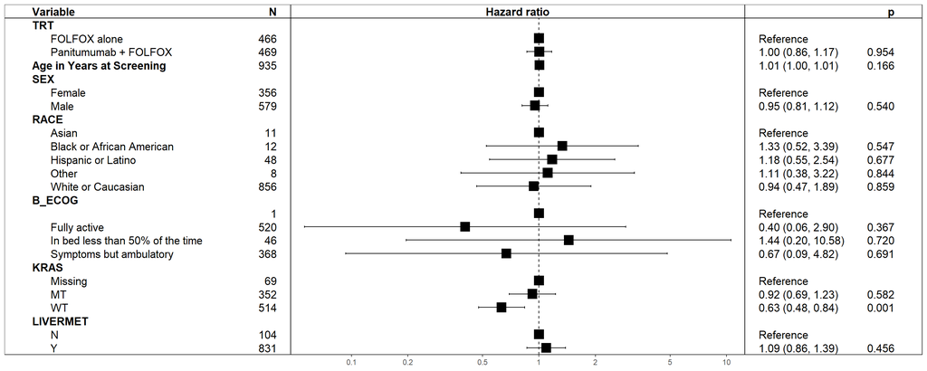

# Survival analysis pitfalls

**Informative censoring** - Censoring should be independent of event times

**Immortal time bias** - Common error that can happen if we condition on the future

**Ignoring competing risks** - When looking at other events than death, then death is a competing event

**Misinterpreting hazard rate ratios** - several risks of misinterpertation, including sensitivity to follow-up time

**Parametric survival models** - If we want to extrapolate survival we can fit a parametric model on the hazard, however there are uncertatinties.

## Examples of use

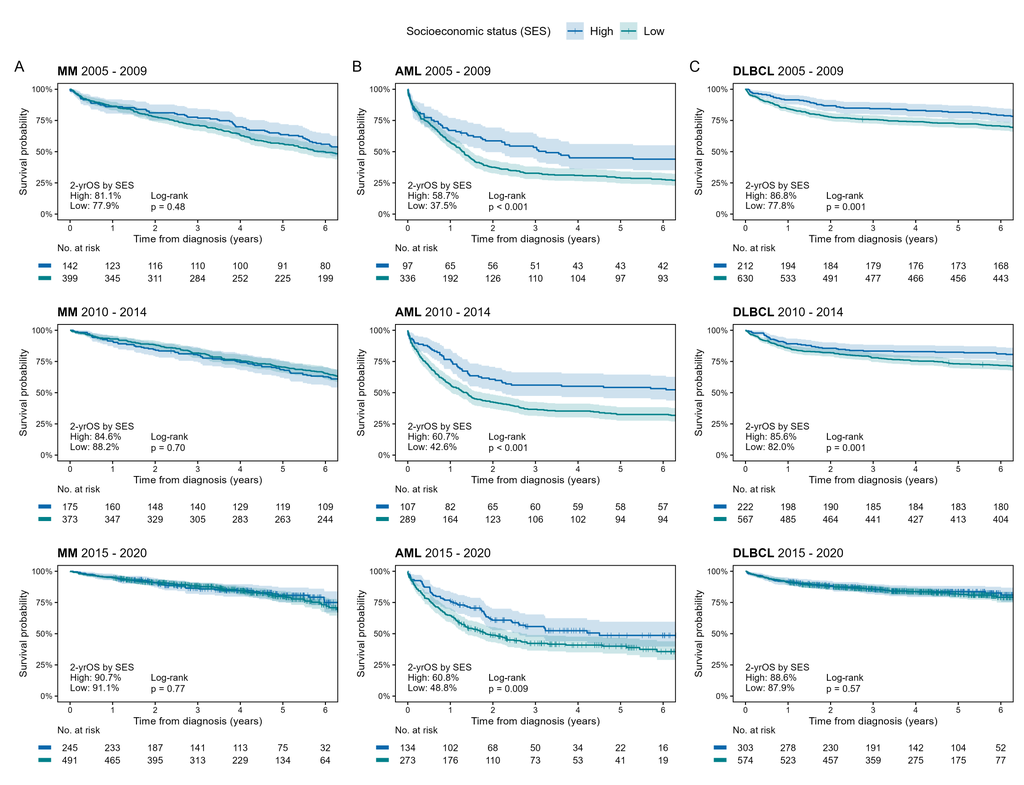

## Examples of use

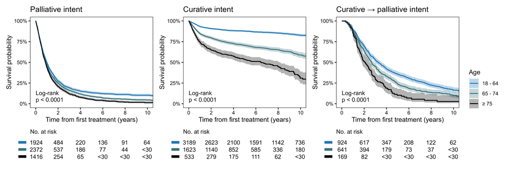

## Examples of use

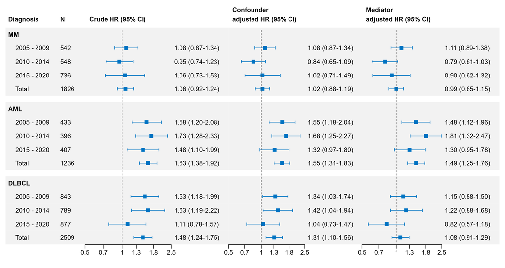

# Assignments

1. Load the data `frmgham2_survival.dta` available on moodle or from `medisr`.

```r
install.packages('medisr', repos = c('https://danmazjen.r-universe.dev', 'https://cloud.r-project.org'))
library(medisr)
data(frmgham2_survival)
```

2. Generate a variable that indicates if a subjects BMI is above 25. Drop patients with missing BMI.
3. Make life-tables for stroke-free survival comparing subjects above/below a BMI of 25 at 1, 3, 5, 10 and 15 years. Outcome indicator; `stroke_or_death` Time to stroke or death; `timestrk`
4. Plot the Kaplan-meier curves for both BMI groups.
5. Run a Log Rank test comparing subjects above/below a BMI of 25.
6. Make a crude Cox regression analysis comparing subjects above/below a BMI of 25.
7. Repeat the Cox regression analysis adjusting for age, sex, current smoking status and diabetes.
8. Repeat above exercises for BMI above 30. How did the results change?

Extra - Try to implement the Kaplan-Meier function in R using a for loop

## Extra - Partial Maximum Likelihood for COXPH

$$L(\beta) = \prod_{I\in D}\frac{exp(Z_I^T \beta)}{\sum_{k\in R(t_1)}exp(Z_k^T \beta)}$$
A cool trick is that this partial maximum likelihood can be easily estimated using an optimizer in R, like GLM models that rely on MLE.

```r
lung <- lung |> filter(!duplicated(time)) # classic Cox does not handle ties, Efron/Breslow

partial_lik <- function(beta, data) {
  da <- arrange(data, time)
  db <- da[da$status == 2,]
  aa <- map_dbl(db$time, ~ if_else(db[db$time == .x, "sex"] == 1, 1, exp(beta)))
  bb <- map_dbl(db$time, ~ nrow(da[da$time >= .x & da$sex == 1,]))
  cc <- map_dbl(db$time, ~ nrow(da[da$time >= .x & da$sex == 2,]) * exp(beta))
  prod(aa / (bb + cc))
}

lung |> optimize(partial_lik, c(-9, 9), maximum = TRUE, tol = 0.000001, data = _) |> pluck("maximum")
```

```
[1] -0.4754432
```

```r
lung |> coxph(Surv(time, status) ~ sex, data = _) |> pluck("coefficients", 1)
```

```
[1] -0.4754431
```

# References

Dimopoulos, Meletios A, Albert Oriol, Hareth Nahi, et al. 2016. “Daratumumab, Lenalidomide, and Dexamethasone for Multiple Myeloma.” *New England Journal of Medicine* 375 (14): 1319–31. https://doi.org/10.1056/NEJMoa1607751.

Moore, Dirk F et al. 2016. *Applied Survival Analysis Using r*. Vol. 473. Springer. https://doi.org/10.1007/978-3-319-31245-3.